# Viabilidad 03

A y B (6 años) con conflicto VAN/TIR (Fisher 13.7%), C de 4 años; k = 6%

# Enunciado

Una empresa debe elegir **una sola** de tres inversiones excluyentes (flujos de caja en k€ al final de cada año; el año 0 es la inversión). A y B duran 6 años; C dura 4 y puede repetirse indefinidamente en las mismas condiciones. La tasa de descuento es del 6%.

1. Calcule el VAN, la TIR y el payback de A y de B. ¿Qué proyecto prefiere cada criterio?

2. Explique por qué VAN y TIR pueden discrepar entre proyectos excluyentes. Calcule la tasa de Fisher (la que iguala los VAN) a partir de los flujos diferenciales A − B y dibuje los dos perfiles de VAN.

3. ¿Para qué tasas de descuento se prefiere A y para cuáles B? ¿Cuál es la decisión correcta a la tasa dada y por qué manda el VAN?

4. C tiene menor vida. Compare C con la mejor de A y B mediante la anualidad equivalente (o la cadena de repeticiones). ¿Cambia la decisión?

Tabla 1: Flujos de caja de las alternativas (k€)

| year | A | B | C |
| --- | --- | --- | --- |
| 0 | -870 | -870 | -520 |
| 1 | 165 | 330 | 230 |
| 2 | 195 | 285 | 230 |
| 3 | 235 | 245 | 230 |
| 4 | 280 | 215 | 230 |
| 5 | 330 | 185 | 0 |
| 6 | 390 | 160 | 0 |

# Resolución

## Apartado 1

1. Calcule el VAN, la TIR y el payback de A y de B. ¿Qué proyecto prefiere cada criterio?

VAN (valor actual neto) a la tasa de descuento, TIR (tasa interna de rentabilidad, la que anula el VAN) y periodo de recuperación (payback) de cada proyecto, con los cálculos:

**A.** VAN = Σ flujo_t/(1 + k)^t = −870.0 + 165.0/1.06¹ + 195.0/1.06² + 235.0/1.06³ + 280.0/1.06⁴ + 330.0/1.06⁵ + 390.0/1.06⁶ = −870.0 + 155.7 + 173.5 + 197.3 + 221.8 + 246.6 + 274.9 = **399.8 k€**. La TIR es la tasa que anula el VAN. Probando tasas: VAN(17%) = 12.2 k€ y VAN(18%) = −14.0 k€ tienen signo distinto, así que la TIR está entre 17% y 18%; interpolando linealmente, TIR ≈ 17% + 1 % × 12.2/(12.2 − (−14.0)) = 17.47%. Afinando (bisección, o =TIR(rango de flujos) en la hoja de cálculo): **TIR = 17.46%**. Comprobación: VAN(17.46%) = 0.0000 ≈ 0. Payback: el acumulado pasa de −275.0 (año 3) a 5.0 (año 4); dentro del año 4 se recuperan los 275.0 k€ que faltaban con un flujo de 280.0: payback = 3 + 275.0/280.0 = **3.98 años**; descontado: el acumulado descontado pasa de −121.7 (año 4) a 124.9 (año 5); dentro del año 5 se recuperan los 121.7 k€ que faltaban con un flujo descontado de 246.6: payback = 4 + 121.7/246.6 = **4.49 años**.

**B.** VAN = Σ flujo_t/(1 + k)^t = −870.0 + 330.0/1.06¹ + 285.0/1.06² + 245.0/1.06³ + 215.0/1.06⁴ + 185.0/1.06⁵ + 160.0/1.06⁶ = −870.0 + 311.3 + 253.6 + 205.7 + 170.3 + 138.2 + 112.8 = **322.0 k€**. La TIR es la tasa que anula el VAN. Probando tasas: VAN(18%) = 14.5 k€ y VAN(19%) = −5.0 k€ tienen signo distinto, así que la TIR está entre 18% y 19%; interpolando linealmente, TIR ≈ 18% + 1 % × 14.5/(14.5 − (−5.0)) = 18.74%. Afinando (bisección, o =TIR(rango de flujos) en la hoja de cálculo): **TIR = 18.74%**. Comprobación: VAN(18.74%) = 0.0000 ≈ 0. Payback: el acumulado pasa de −10.0 (año 3) a 205.0 (año 4); dentro del año 4 se recuperan los 10.0 k€ que faltaban con un flujo de 215.0: payback = 3 + 10.0/215.0 = **3.05 años**; descontado: el acumulado descontado pasa de −99.3 (año 3) a 71.0 (año 4); dentro del año 4 se recuperan los 99.3 k€ que faltaban con un flujo descontado de 170.3: payback = 3 + 99.3/170.3 = **3.58 años**.

Tabla 2: Criterios para A y B

|  | VAN (k€) | TIR | payback (años) | payback descontado |
| --- | --- | --- | --- | --- |
| A | 399.8 | 17.46% | 3.98 | 4.49 |
| B | 322.0 | 18.74% | 3.05 | 3.58 |

**Respuesta:** el VAN prefiere A (399.8 frente a 322.0 k€); la TIR prefiere B (18.74% frente a 17.46%); el payback prefiere B (recupera la inversión en 3.05 años frente a 3.98). VAN y TIR discrepan.

## Apartado 2

2. Explique por qué VAN y TIR pueden discrepar entre proyectos excluyentes. Calcule la tasa de Fisher (la que iguala los VAN) a partir de los flujos diferenciales A − B y dibuje los dos perfiles de VAN.

La TIR es una medida *relativa* (rentabilidad por euro y año) y supone la reinversión de los flujos a la propia TIR; el VAN es *absoluto* (euros de valor creado a la tasa de descuento). Cuando los proyectos tienen distinto perfil temporal (A cobra tarde, B cobra pronto) sus perfiles de VAN se cruzan: a la tasa de Fisher ambos valen lo mismo. Como VAN_A − VAN_B es el VAN de los flujos diferenciales A − B, la tasa de Fisher es la TIR de esos flujos.

| año | 0 | 1 | 2 | 3 | 4 | 5 | 6 |
| --- | --- | --- | --- | --- | --- | --- | --- |
| A | -870 | 165 | 195 | 235 | 280 | 330 | 390 |
| B | -870 | 330 | 285 | 245 | 215 | 185 | 160 |
| A − B | 0 | -165 | -90 | -10 | 65 | 145 | 230 |

Flujos A − B: Su TIR es la tasa que anula su VAN. Probando tasas: VAN(13%) = 5.6 k€ y VAN(14%) = −2.2 k€ tienen signo distinto, así que la TIR está entre 13% y 14%; interpolando linealmente, TIR ≈ 13% + 1 % × 5.6/(5.6 − (−2.2)) = 13.72%. Afinando (bisección, o =TIR(rango de flujos) en la hoja de cálculo): **TIR = 13.72%**. Comprobación: VAN(13.72%) = 0.0000 ≈ 0.

**Respuesta:** tasa de Fisher = 13.72%; a esa tasa VAN_A = 107.1 k€ = VAN_B = 107.1 k€ (los perfiles se cortan en el gráfico).

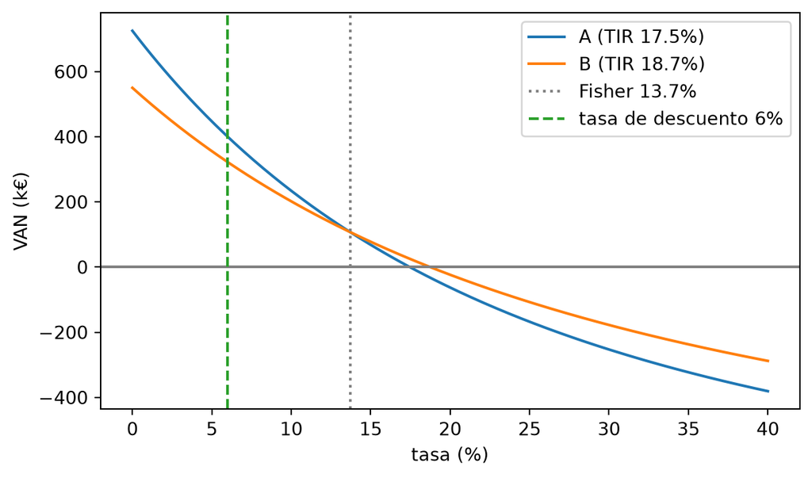

Figura 1: Perfiles de VAN de A y B

## Apartado 3

3. ¿Para qué tasas de descuento se prefiere A y para cuáles B? ¿Cuál es la decisión correcta a la tasa dada y por qué manda el VAN?

**Respuesta:** para tasas por debajo de la de Fisher (13.72%) se prefiere A (sus flujos tardíos valen más cuando el descuento es suave); por encima, B (hasta su TIR, 18.74%; por encima de ambas TIR ninguno es viable). A la tasa dada (6% < 13.72%) la decisión correcta es **A**, la de mayor VAN (399.8 frente a 322.0 k€): el objetivo es maximizar el valor creado en euros, y la TIR, al ser relativa e implicar reinversión a la propia TIR, no compara bien proyectos de distinto perfil temporal.

## Apartado 4

4. C tiene menor vida. Compare C con la mejor de A y B mediante la anualidad equivalente (o la cadena de repeticiones). ¿Cambia la decisión?

Un VAN de 4 años y uno de 6 no son comparables: el de menor vida deja libre el dinero antes y puede repetirse. La anualidad equivalente reparte cada VAN en una renta constante durante su vida, AE = VAN · k / [1 − (1 + k)^−n]; la cadena de repeticiones suma el VAN de cada repetición descontado hasta una vida común (el mínimo común múltiplo de las vidas).

|  | VAN (k€) | vida | AE = VAN · k / [1 − (1 + k)^−n] |
| --- | --- | --- | --- |
| A | 399.8 | 6 | 399.8 × 0.06 / [1 − 1.06^−6] = 81.31 |
| B | 322.0 | 6 | 322.0 × 0.06 / [1 − 1.06^−6] = 65.49 |
| C | 277.0 | 4 | 277.0 × 0.06 / [1 − 1.06^−4] = 79.93 |

VAN de C: VAN = Σ flujo_t/(1 + k)^t = −520.0 + 230.0/1.06¹ + 230.0/1.06² + 230.0/1.06³ + 230.0/1.06⁴ = −520.0 + 217.0 + 204.7 + 193.1 + 182.2 = **277.0 k€**. Cadenas de repeticiones hasta 12 años: A, 399.8 + 399.8/1.06⁶ = 681.7 k€; C, 277.0 + 277.0/1.06⁴ + 277.0/1.06⁸ = 670.1 k€. **Respuesta:** la decisión no cambia, sigue siendo A: su anualidad equivalente (81.3 k€/año) supera la de C (79.9); la cadena de repeticiones da la misma conclusión.